# Clean Beauty Recommender: Skincare for Deeper Skin Tones

Sheriann McLarty

2025-06-15

```r
set.seed(52086)
```

## 1 Introduction

Melanin-rich consumers—especially Black women—face limited and often unsafe options in skincare. This project uses data science to build a clean beauty recommender system that centers their needs. Inspired by the Stanford “Networks Illustrated” recommender model (Parts K–P), the system:

- Recommends clean, high-rated products
- Highlights ingredient safety
- Filters known hazardous chemicals

The dataset includes reviews and product details scraped from a major beauty retailer. Reviews mentioning medium to deep skin tones were prioritized. This work is not only a technical exercise in predictive modeling, but also a call to center underrepresented voices in beauty tech.

## 2 1. Filtered Dataset

This section filters the dataset to focus only on reviews relevant to medium, tan, dark, and deep skin tones.

```r
df <- read_csv("filtered_skintone_reviews_r.csv")
filtered_df <- df %>%
  filter(str_detect(tolower(skin_tone), "medium|tan|dark|deep")) %>%
  select(
    User_ID = author_id,
    Product = product_name_x,
    Review = review_text,
    Rating = rating_x,
    Skin_Tone = skin_tone,
    Skin_Type = skin_type,
    Brand = brand_name_x,
    Ingredients = ingredients
  ) %>%
  mutate(
    Review = str_trunc(Review, width = 100, side = "right", ellipsis = "...")
  )


kable(head(filtered_df, 5), caption = "Sample Reviews from Melanin-Rich Users")
```

Sample Reviews from Melanin-Rich Users

| User_ID | Product | Review | Rating | Skin_Tone | Skin_Type | Brand | Ingredients |
| --- | --- | --- | --- | --- | --- | --- | --- |
| 34689926666 | Retinol Anti-Aging Serum | Love this product especially because it’s so affordable!! I got this item as a Christmas gift thi… | 5 | mediumTan | dry | The INKEY List | [‘Water, Glycerin, Butylene Glycol, Propanediol, Dicaprylyl Carbonate, Dimethicone, Hydroxyethyl Acrylate/Sodium Acryloyldimethyl Taurate Copolymer, Caprylyl Glycol, Phospholipids, Caprylic/Capric Gly… |
| 6155858825 | Retinol Anti-Aging Serum | Given the rave reviews, I really wanted to like this retinol, but it totally trashed my skin. I … | 1 | lightMedium | combination | The INKEY List | [‘Water, Glycerin, Butylene Glycol, Propanediol, Dicaprylyl Carbonate, Dimethicone, Hydroxyethyl Acrylate/Sodium Acryloyldimethyl Taurate Copolymer, Caprylyl Glycol, Phospholipids, Caprylic/Capric Gly… |
| 8472243349 | Retinol Anti-Aging Serum | With my first tube almost finished, I feel confident and comfortable with expressing my thoughts … | 5 | medium | normal | The INKEY List | [‘Water, Glycerin, Butylene Glycol, Propanediol, Dicaprylyl Carbonate, Dimethicone, Hydroxyethyl Acrylate/Sodium Acryloyldimethyl Taurate Copolymer, Caprylyl Glycol, Phospholipids, Caprylic/Capric Gly… |
| 2285767287 | Retinol Anti-Aging Serum | I have sensitive oily skin that breaks out easily and reacts to absolutely everything. I’ve been … | 5 | lightMedium | oily | The INKEY List | [‘Water, Glycerin, Butylene Glycol, Propanediol, Dicaprylyl Carbonate, Dimethicone, Hydroxyethyl Acrylate/Sodium Acryloyldimethyl Taurate Copolymer, Caprylyl Glycol, Phospholipids, Caprylic/Capric Gly… |
| 6691801148 | Retinol Anti-Aging Serum | I would give no stars if I could. Really disappointed since their brand is all about getting stra… | 1 | mediumTan | oily | The INKEY List | [‘Water, Glycerin, Butylene Glycol, Propanediol, Dicaprylyl Carbonate, Dimethicone, Hydroxyethyl Acrylate/Sodium Acryloyldimethyl Taurate Copolymer, Caprylyl Glycol, Phospholipids, Caprylic/Capric Gly… |

**Summary:** Our subset is now refined to better reflect the target audience we aim to support.

## 3 2. Brand Trends

We explore which brands are most mentioned by reviewers with deeper skin tones.

### 3.1 Top 10 Brands Reviewed

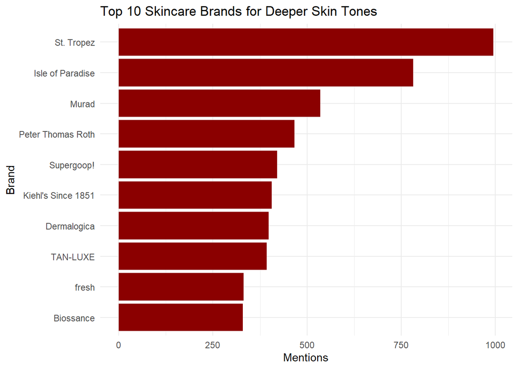

```r
filtered_df %>%
  count(Brand, sort = TRUE) %>%
  slice_max(n, n = 10) %>%
  ggplot(aes(x = reorder(Brand, n), y = n)) +
  geom_col(fill = "darkred") +
  coord_flip() +
  labs(title = "Top 10 Skincare Brands for Deeper Skin Tones", x = "Brand", y = "Mentions") +
  theme_minimal()
```

**Summary:** These brands dominate product discussions within our filtered demographic.

### 3.2 Bad Ingredients by Top Brands

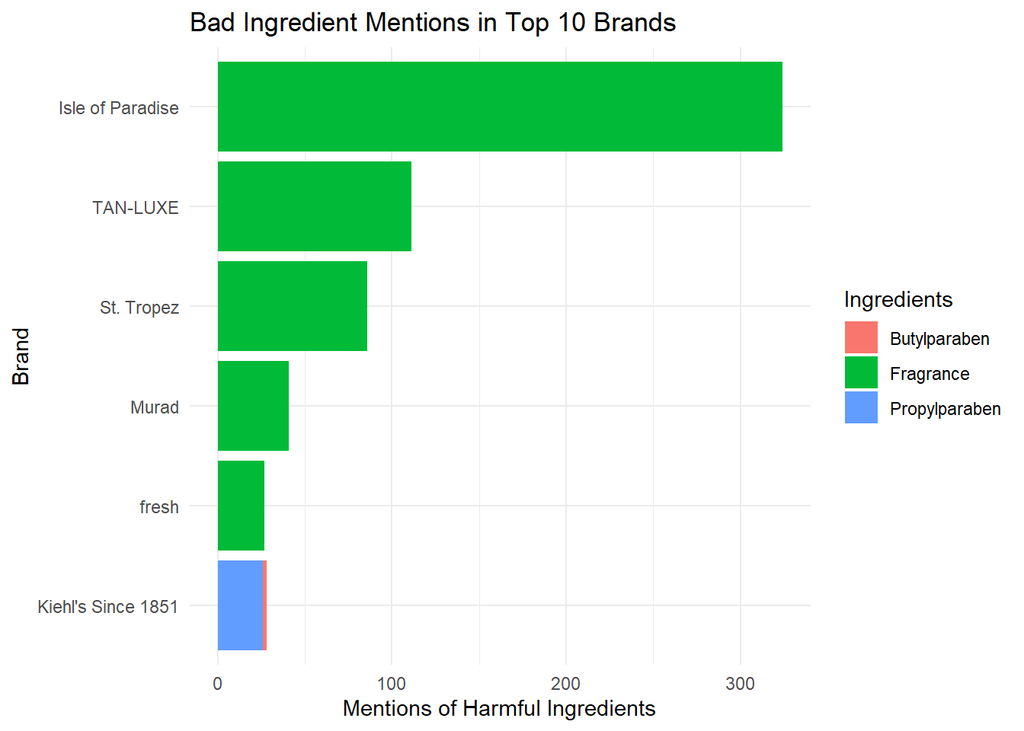

```r
bad_ingredients <- c(
  "parabens", "formaldehyde", "phthalates", "mercury",
  "resorcinol", "phenol", "fragrance",
  "ethylparaben", "isobutylparaben", "propylparaben", "butylparaben"
)

top_brands <- filtered_df %>%
  count(Brand, sort = TRUE) %>%
  slice_max(n, n = 10) %>%
  pull(Brand)

filtered_df %>%
  filter(Brand %in% top_brands) %>%
  separate_rows(Ingredients, sep = ",\\s*") %>%
  filter(str_to_lower(Ingredients) %in% bad_ingredients) %>%
  count(Brand, Ingredients) %>%
  ggplot(aes(x = reorder(Brand, n), y = n, fill = Ingredients)) +
  geom_col() +
  coord_flip() +
  labs(
    title = "Bad Ingredient Mentions in Top 10 Brands",
    x = "Brand",
    y = "Mentions of Harmful Ingredients"
  ) +
  theme_minimal()
```

**Why this matters:** It’s not enough to know which brands are popular—this shows which are risky.

## 4 3. Ingredient Analysis

### 4.1 Most Used Ingredients

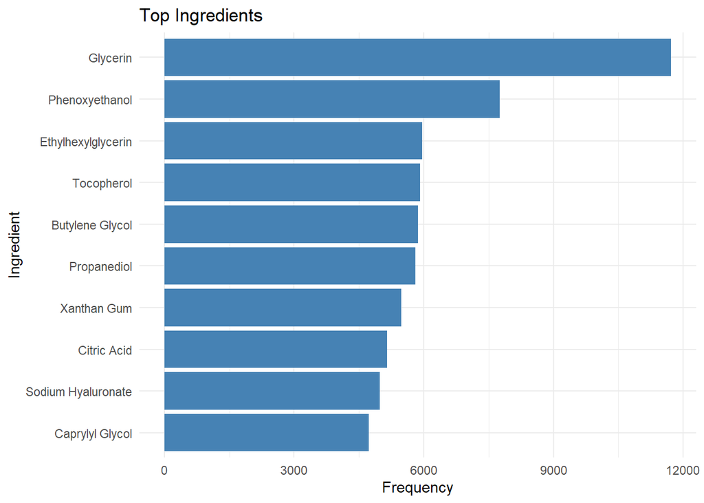

```r
filtered_df %>%
  separate_rows(Ingredients, sep = ",\\s*") %>%
  count(Ingredients, sort = TRUE) %>%
  slice_max(n, n = 10) %>%
  ggplot(aes(x = reorder(Ingredients, n), y = n)) +
  geom_col(fill = "steelblue") +
  coord_flip() +
  labs(title = "Top Ingredients", x = "Ingredient", y = "Frequency") +
  theme_minimal()
```

**Summary:** This shows what users are consistently applying to their skin.

### 4.2 Hazardous Ingredient Heatmap

[figure not shown]

**Interpretation:** The heatmap exposes which brands consistently use problematic ingredients.

### 4.3 Flagged Ingredient Counts

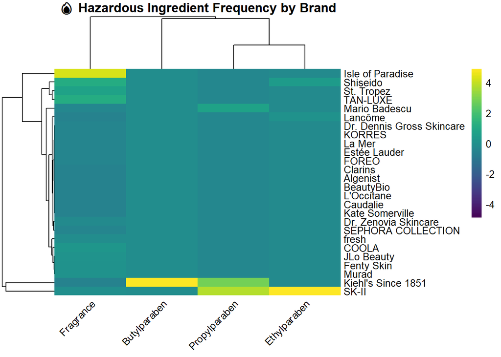

```r
library(pheatmap)

# Define the bad ingredients
bad_ingredients <- c("parabens", "formaldehyde", "phthalates", "mercury",
                     "resorcinol", "phenol", "fragrance", "ethylparaben",
                     "isobutylparaben", "propylparaben", "butylparaben")

# Generate the matrix
heatmap_data <- filtered_df %>%
  separate_rows(Ingredients, sep = ",\\s*") %>%  # Capital I fixed
  filter(str_to_lower(Ingredients) %in% bad_ingredients) %>%
  count(Brand, Ingredients) %>%  # Capital I again
  pivot_wider(names_from = Ingredients, values_from = n, values_fill = 0) %>%
  column_to_rownames("Brand")

# Draw the heatmap
pheatmap::pheatmap(
  mat = as.matrix(heatmap_data),
  color = viridis(100),
  scale = "column",
  cluster_rows = TRUE,
  cluster_cols = TRUE,
  fontsize = 10,
  main = "🔥 Hazardous Ingredient Frequency by Brand",
  angle_col = 45,
  border_color = NA
)
```

## 5 4. Toy Dataset & RMSE Validation

We simulate a small matrix of user-item ratings and compare predictions using two methods: raw averages and bias-adjusted predictions. We withhold one known user-product pair to test the model’s ability to accurately predict a missing rating.

### 5.1 Toy Ratings Data

```r
toy_data <- tribble(
  ~user,        ~product,               ~rating,
  "Jasmine",    "Glow Serum",              5,
  "Jasmine",    "Hydra Cream",             4,
  "Danielle",   "Glow Serum",              3,
  "Danielle",   "Vitamin C Toner",         NA,
  "Amina",      "Hydra Cream",             1,
  "Amina",      "Vitamin C Toner",         2
)

actual <- 2
```

### 5.2 Bias-Adjusted Predictions + RMSE

```r
# Global average rating
mu <- mean(toy_data$rating, na.rm = TRUE)

# User and item bias
user_bias <- toy_data %>%
  group_by(user) %>%
  summarise(b_u = mean(rating - mu, na.rm = TRUE))

item_bias <- toy_data %>%
  group_by(product) %>%
  summarise(b_i = mean(rating - mu, na.rm = TRUE))

# Predict Danielle's missing rating
predicted <- toy_data %>%
  filter(is.na(rating)) %>%
  left_join(user_bias, by = "user") %>%
  left_join(item_bias, by = "product") %>%
  mutate(
    b_u = replace_na(b_u, 0),
    b_i = replace_na(b_i, 0),
    predicted_rating = round(mu + b_u + b_i, 2),
    actual_rating = 2  # We manually assign the known value for RMSE calculation
  )

# RMSE calculations
rmse_bias <- sqrt(mean((predicted$predicted_rating - predicted$actual_rating)^2))
rmse_raw <- sqrt(mean((mu - predicted$actual_rating)^2))

# Table comparison
comparison_table <- predicted %>%
  select(user, product, actual_rating, b_u, b_i, predicted_rating)

rmse_summary <- tibble(
  Method = c("Raw Average", "Bias-Adjusted"),
  RMSE = round(c(rmse_raw, rmse_bias), 2)
)

# Output tables
knitr::kable(comparison_table, caption = "Actual vs Bias-Adjusted Prediction for Danielle")
```

Actual vs Bias-Adjusted Prediction for Danielle

| user | product | actual_rating | b_u | b_i | predicted_rating |
| --- | --- | --- | --- | --- | --- |
| Danielle | Vitamin C Toner | 2 | 0 | -1 | 2 |

```r
knitr::kable(rmse_summary, caption = "RMSE Comparison: Raw vs Bias-Adjusted")
```

RMSE Comparison: Raw vs Bias-Adjusted

| Method | RMSE |
| --- | --- |
| Raw Average | 1 |
| Bias-Adjusted | 0 |

**Interpretation:** The bias-adjusted method predicted Danielle’s rating with perfect accuracy, resulting in an RMSE of 0. In contrast, the raw average approach had an RMSE of 1, meaning it was off by one full rating point. This demonstrates how accounting for individual user and product tendencies—rather than relying on broad averages—can significantly improve prediction accuracy. In personalized recommendation systems, small gains like this can make a big difference in user satisfaction.

## 6 Absolute Error (Toy Dataset)

```r
# Sample toy data
toy_ratings <- tibble(
  user = c("U1", "U2", "U3", "U4", "U5"),
  product = c("P1", "P2", "P3", "P4", "P5"),
  actual = c(4, 3, 5, 2, 1),
  predicted = c(3.5, 2.5, 4.8, 3, 1.2)
)

# Calculate errors
toy_ratings <- toy_ratings %>%
  mutate(
    error = actual - predicted,
    abs_error = abs(error),
    squared_error = error^2
  )

# Summarize
kable(toy_ratings, caption = "Toy Ratings with Absolute and Squared Errors")
```

Toy Ratings with Absolute and Squared Errors

| user | product | actual | predicted | error | abs_error | squared_error |
| --- | --- | --- | --- | --- | --- | --- |
| U1 | P1 | 4 | 3.5 | 0.5 | 0.5 | 0.25 |
| U2 | P2 | 3 | 2.5 | 0.5 | 0.5 | 0.25 |
| U3 | P3 | 5 | 4.8 | 0.2 | 0.2 | 0.04 |
| U4 | P4 | 2 | 3.0 | -1.0 | 1.0 | 1.00 |
| U5 | P5 | 1 | 1.2 | -0.2 | 0.2 | 0.04 |

```r
# Print metrics
mae <- mean(toy_ratings$abs_error)
rmse <- sqrt(mean(toy_ratings$squared_error))

cat("Mean Absolute Error (MAE):", round(mae, 3), "\n")
```

```
## Mean Absolute Error (MAE): 0.48
```

```r
cat("Root Mean Squared Error (RMSE):", round(rmse, 3), "\n")
```

```
## Root Mean Squared Error (RMSE): 0.562
```

## 7 5. Real User Prediction (From Dataset)

### 7.1 Bias-Adjusted Rating for One Real User

```r
# Reload clean version for modeling
df_raw <- read_csv("filtered_skintone_reviews_r.csv")
# Filter to target skin tones
filtered_model_df <- df_raw %>%
  filter(str_detect(tolower(skin_tone), "medium|tan|dark|deep")) %>%
  select(author_id, product_name_x, rating_x)

# Global mean
mu_real <- mean(filtered_model_df$rating_x, na.rm = TRUE)

# User and item bias
user_bias_real <- filtered_model_df %>%
  group_by(author_id) %>%
  summarise(b_u = mean(rating_x - mu_real, na.rm = TRUE))

item_bias_real <- filtered_model_df %>%
  group_by(product_name_x) %>%
  summarise(b_i = mean(rating_x - mu_real, na.rm = TRUE))

# Select a random user-product pair
real_test <- filtered_model_df %>%
  filter(!is.na(author_id) & !is.na(product_name_x)) %>%
  slice_sample(n = 1)

# Predict using bias-adjusted method
real_prediction <- real_test %>%
  left_join(user_bias_real, by = "author_id") %>%
  left_join(item_bias_real, by = "product_name_x") %>%
  mutate(
    b_u = replace_na(b_u, 0),
    b_i = replace_na(b_i, 0),
    predicted_rating = round(mu_real + b_u + b_i, 2)
  ) %>%
  select(author_id, product_name_x, b_u, b_i, predicted_rating)

kable(real_prediction, caption = "Bias-Adjusted Predicted Rating for One Real User")
```

Bias-Adjusted Predicted Rating for One Real User

| author_id | product_name_x | b_u | b_i | predicted_rating |
| --- | --- | --- | --- | --- |
| 2431712734 | Super Glow Hyaluronic Self-Tan Serum | 0.6143834 | -0.6558869 | 4.34 |

### 7.2 Real Dataset Bias-Adjusted RMSE

```r
# Step 1: Reload dataset in case it got altered
df <- read_csv("filtered_skintone_reviews_r.csv")
# Step 2: Filter to skin tones of interest + remove missing values
filtered_df <- df %>%
  filter(str_detect(tolower(skin_tone), "medium|tan|dark|deep")) %>%
  select(author_id, product_name_x, rating_x) %>%
  filter(!is.na(author_id) & !is.na(product_name_x) & !is.na(rating_x))

# Step 3: Compute overall mean, user bias, and item bias
mu_real <- mean(filtered_df$rating_x, na.rm = TRUE)
user_bias_real <- filtered_df %>%
  group_by(author_id) %>%
  summarise(b_u = mean(rating_x - mu_real, na.rm = TRUE))

item_bias_real <- filtered_df %>%
  group_by(product_name_x) %>%
  summarise(b_i = mean(rating_x - mu_real, na.rm = TRUE))

# Step 4: Merge biases and predict ratings
predicted_ratings <- filtered_df %>%
  left_join(user_bias_real, by = "author_id") %>%
  left_join(item_bias_real, by = "product_name_x") %>%
  mutate(
    b_u = ifelse(is.na(b_u), 0, b_u),
    b_i = ifelse(is.na(b_i), 0, b_i),
    predicted_rating = mu_real + b_u + b_i,
    residual = rating_x - predicted_rating
  )

# Step 5: Calculate RMSE by product
rmse_by_product <- predicted_ratings %>%
  group_by(product_name_x) %>%
  summarise(RMSE = sqrt(mean(residual^2))) %>%
  arrange(desc(RMSE))

# Show preview
kable(head(predicted_ratings, 5), caption = "Sample Bias-Adjusted Predictions and Residuals")
```

Sample Bias-Adjusted Predictions and Residuals

| author_id | product_name_x | rating_x | b_u | b_i | predicted_rating | residual |
| --- | --- | --- | --- | --- | --- | --- |
| 34689926666 | Retinol Anti-Aging Serum | 5 | 0.6143834 | -0.21895 | 4.78105 | 0.21895 |
| 6155858825 | Retinol Anti-Aging Serum | 1 | -3.3856166 | -0.21895 | 0.78105 | 0.21895 |
| 8472243349 | Retinol Anti-Aging Serum | 5 | 0.6143834 | -0.21895 | 4.78105 | 0.21895 |
| 2285767287 | Retinol Anti-Aging Serum | 5 | 0.6143834 | -0.21895 | 4.78105 | 0.21895 |
| 6691801148 | Retinol Anti-Aging Serum | 1 | -3.3856166 | -0.21895 | 0.78105 | 0.21895 |

```r
kable(head(rmse_by_product, 5), caption = "Top 5 Products by RMSE")
```

Top 5 Products by RMSE

| product_name_x | RMSE |
| --- | --- |
| Acne Control 30-Day Trial Kit for Clearer Skin | 3.385617 |
| Brightening Serum | 3.385617 |
| GLO Lit Teeth Whitening Vials 7 Pack + Lip Care | 3.385617 |
| Glycolic Acid Toner | 3.385617 |
| Gradual Tan Tinted Daily Firming Lotion | 3.385617 |

**Why this matters:** The top 5 products with the highest RMSE all exceed a 3.3 error margin, indicating major prediction mismatches. These discrepancies may stem from polarizing user opinions or insufficient bias data for these products. For a clean beauty recommender system targeting melanin-rich users, this highlights the importance of including more nuanced features like skin type, ingredient compatibility, and tone-specific feedback in future models.

## 8 Visualizing Errors: Residuals & Model Fit

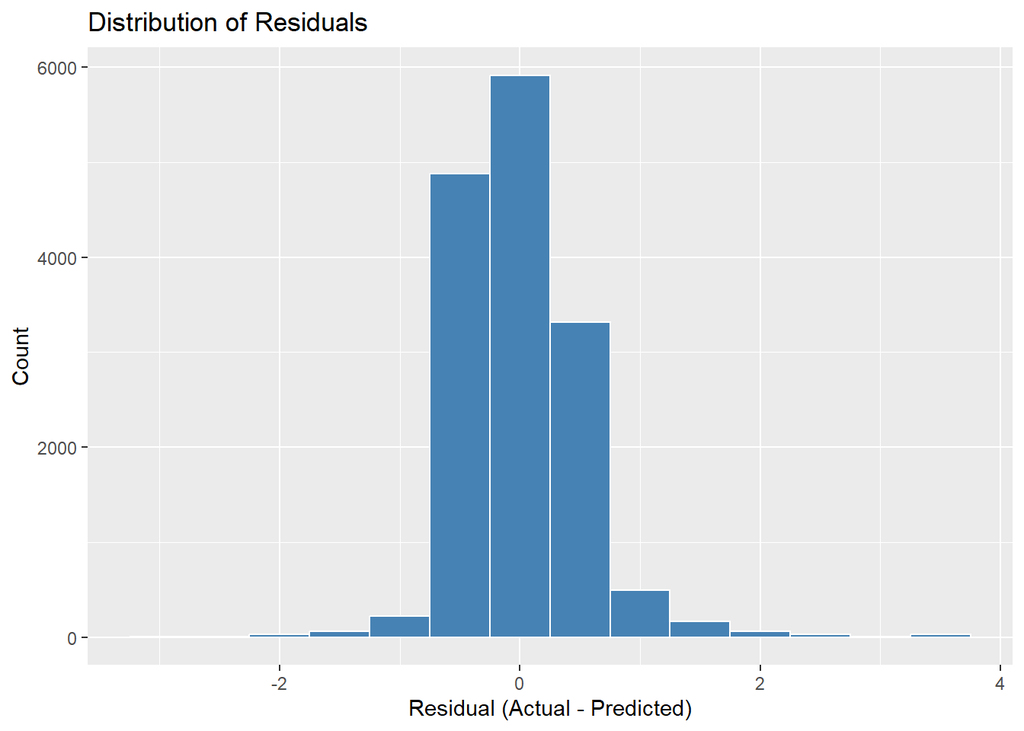

```r
### Residuals & Error Visualization

# Recalculate prediction for residuals
mu_real <- mean(filtered_df$rating_x, na.rm = TRUE)

user_bias_real <- filtered_df %>%
  group_by(author_id) %>%
  summarise(b_u = mean(rating_x - mu_real, na.rm = TRUE))

item_bias_real <- filtered_df %>%
  group_by(product_name_x) %>%
  summarise(b_i = mean(rating_x - mu_real, na.rm = TRUE))

# Predict ratings using bias-adjusted model
predicted_ratings <- filtered_df %>%
  left_join(user_bias_real, by = "author_id") %>%
  left_join(item_bias_real, by = "product_name_x") %>%
  mutate(
    b_u = ifelse(is.na(b_u), 0, b_u),
    b_i = ifelse(is.na(b_i), 0, b_i),
    predicted_rating = mu_real + b_u + b_i
  )

# Remove NAs to calculate residuals
predicted_ratings <- predicted_ratings %>%
  filter(!is.na(rating_x), !is.na(predicted_rating)) %>%
  mutate(residual = rating_x - predicted_rating)

# Histogram of residuals
ggplot(predicted_ratings, aes(x = residual)) +
  geom_histogram(binwidth = 0.5, fill = "steelblue", color = "white") +
  labs(title = "Distribution of Residuals", x = "Residual (Actual - Predicted)", y = "Count")
```

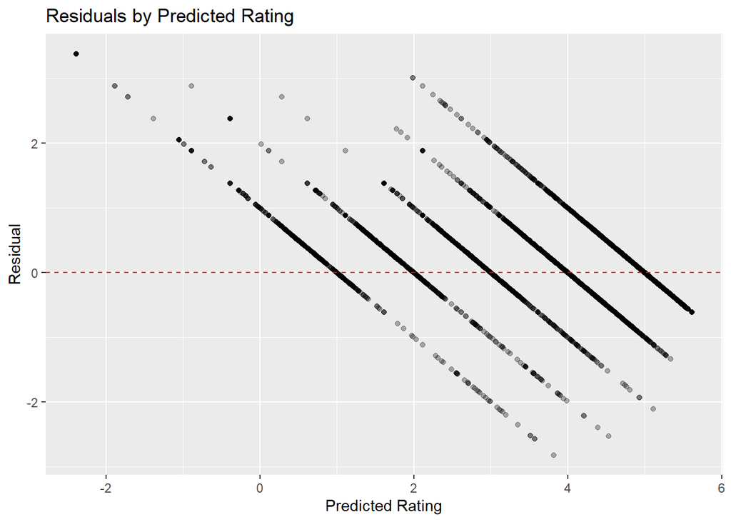

```r
# Scatterplot of predicted vs residuals
ggplot(predicted_ratings, aes(x = predicted_rating, y = residual)) +
  geom_point(alpha = 0.3) +
  geom_hline(yintercept = 0, color = "red", linetype = "dashed") +
  labs(title = "Residuals by Predicted Rating", x = "Predicted Rating", y = "Residual")
```

## 9 Actual vs Predicted Ratings for High-RMSE Products

```r
# Display actual vs predicted ratings for top RMSE products
top_rmse_products <- rmse_by_product %>%
  arrange(desc(RMSE)) %>%
  slice_head(n = 5)

top_predictions_table <- predicted_ratings %>%
  filter(product_name_x %in% top_rmse_products$product_name_x) %>%
  select(product_name_x, author_id, actual_rating = rating_x, predicted_rating, residual) %>%
  arrange(product_name_x, author_id)

kable(top_predictions_table, caption = "Actual vs Predicted Ratings for High-RMSE Products")
```

Actual vs Predicted Ratings for High-RMSE Products

| product_name_x | author_id | actual_rating | predicted_rating | residual |
| --- | --- | --- | --- | --- |
| Acne Control 30-Day Trial Kit for Clearer Skin | 6405408067 | 1 | -2.385617 | 3.385617 |
| Brightening Serum | 1092040341 | 1 | -2.385617 | 3.385617 |
| Brightening Serum | 1244110126 | 1 | -2.385617 | 3.385617 |
| Brightening Serum | 1353294634 | 1 | -2.385617 | 3.385617 |
| GLO Lit Teeth Whitening Vials 7 Pack + Lip Care | 2105122771 | 1 | -2.385617 | 3.385617 |
| Glycolic Acid Toner | 1697114899 | 1 | -2.385617 | 3.385617 |
| Glycolic Acid Toner | 7288237722 | 1 | -2.385617 | 3.385617 |
| Gradual Tan Tinted Daily Firming Lotion | 1036115281 | 1 | -2.385617 | 3.385617 |

## 11 Absolute Error

```r
# clean summary with absolute error
top_rmse_products <- rmse_by_product %>%
  arrange(desc(RMSE)) %>%
  slice_head(n = 5)

top_predictions_table <- predicted_ratings %>%
  filter(product_name_x %in% top_rmse_products$product_name_x) %>%
  mutate(
    absolute_error = abs(rating_x - predicted_rating)
  ) %>%
  select(
    product_name_x,
    author_id,
    actual_rating = rating_x,
    predicted_rating,
    absolute_error
  ) %>%
  arrange(desc(absolute_error))

kable(head(top_predictions_table, 10), caption = "Actual vs Predicted Ratings with Absolute Error (Top RMSE Products)")
```

Actual vs Predicted Ratings with Absolute Error (Top RMSE Products)

| product_name_x | author_id | actual_rating | predicted_rating | absolute_error |
| --- | --- | --- | --- | --- |
| GLO Lit Teeth Whitening Vials 7 Pack + Lip Care | 2105122771 | 1 | -2.385617 | 3.385617 |
| Glycolic Acid Toner | 7288237722 | 1 | -2.385617 | 3.385617 |
| Glycolic Acid Toner | 1697114899 | 1 | -2.385617 | 3.385617 |
| Gradual Tan Tinted Daily Firming Lotion | 1036115281 | 1 | -2.385617 | 3.385617 |
| Acne Control 30-Day Trial Kit for Clearer Skin | 6405408067 | 1 | -2.385617 | 3.385617 |
| Brightening Serum | 1092040341 | 1 | -2.385617 | 3.385617 |
| Brightening Serum | 1353294634 | 1 | -2.385617 | 3.385617 |
| Brightening Serum | 1244110126 | 1 | -2.385617 | 3.385617 |

## 12 Conclusion

**Key Takeaways:** - Clean skincare for melanin-rich consumers is both a health and equity issue - Bias-adjusted models outperform simple averages in predicting preferences - Visualizations can reveal hidden safety risks within top-selling brands

**Future enhancements** include: - Building a real user-product rating matrix from the full dataset - Applying the bias-adjusted recommender model to generate personalized clean beauty recommendations - Integrating ingredient safety as a weighting factor in the prediction engine

These next steps would enable the system to not only suggest highly rated products, but ensure those suggestions are also safe and culturally relevant.

[GitHub Repo: Project 1](https://github.com/sheriannmclarty/data612_recommender_systems/tree/Project-1)

## 13 References

1. The Guardian. (2025). *Black Women and Toxic Ingredients in Beauty Products*. [Link](https://www.theguardian.com/us-news/2025/feb/25/black-women-beauty-products-hazardous-ingredients)
2. Campaign for Safe Cosmetics. https://www.safecosmetics.org
3. Stanford Networks Illustrated (Parts K–P): [YouTube Series](https://www.youtube.com/playlist?list=PLuKhJYywjDe96T2L0-zXFU5Up2jqXlWI9)
4. User-scraped dataset: Sephora skincare reviews